# STAT 425 - Midterm 2 - Data Analysis

Josh Janda

09 April, 2020

```r
library(faraway)
library(tidyverse)
library(lmtest)
library(nlme)
```

## Problem 1.

Using the cheddar data, fit a linear model with taste as a response and the other three variables as a predictors.

```r
lin_ched = lm(taste ~ ., data = cheddar)
```

### A.

Suppose that the observations were taken in time order. Create a time variable. Plot the residuals of the model against time and comment on what can be seen.

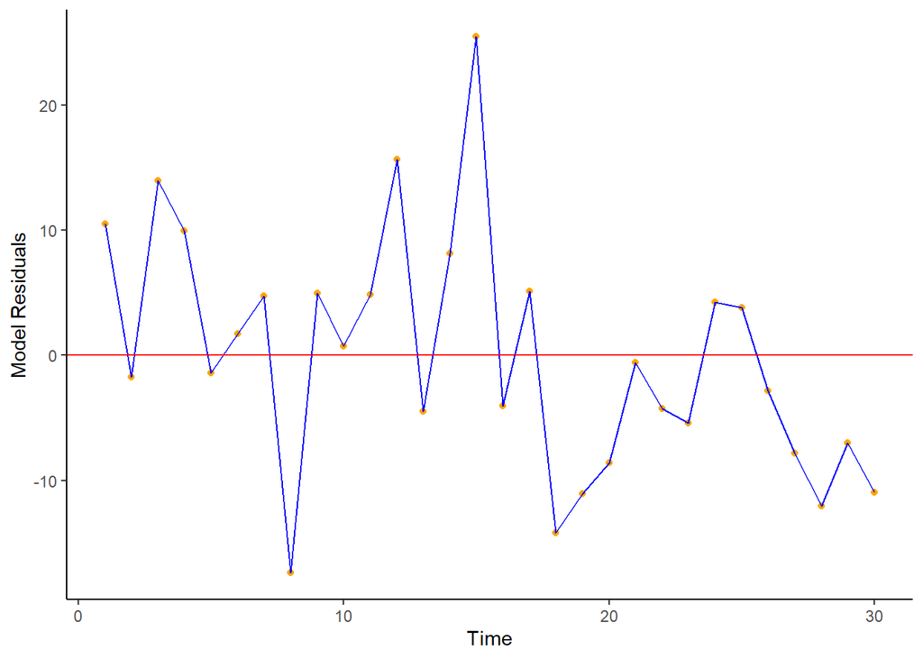

```r
ched_res = lin_ched$residuals
time = 1:length(ched_res)

res_df = data.frame(res = ched_res,
                    time = time)

ggplot(res_df, aes(x = time, y = res)) +
  geom_point(color = 'orange') +
  geom_line(color = 'blue') +
  geom_hline(yintercept = 0, color = 'red') +
  labs(x = 'Time', y = 'Model Residuals') +
  theme(panel.background = element_blank(),
        axis.line = element_line(color = 'black'))
```

Looking at the plot above, I can see that there is definitely some correlation between the residuals. There is not a lot of randomness in the points, and there are multiple instances of multiple residuals being positive or multiple being negative in a row. This multiple positive/negative values in a row indicate autocorrelation in the residuals.

### B.

Fit a GLS model with the same form as above, but now allow for an AR(1) correlation among the errors. Is there evidence of such a correlation?

```r
gls_ched = gls(taste ~ ., correlation = corARMA(p = 1), data = cheddar)
summary(gls_ched)
```

```
## Generalized least squares fit by REML
##   Model: taste ~ .
##   Data: cheddar
##      AIC      BIC  logLik
##   214.94 222.4886 -101.47
##
## Correlation Structure: AR(1)
##  Formula: ~1
##  Parameter estimate(s):
##       Phi
## 0.2641944
##
## Coefficients:
##                  Value Std.Error   t-value p-value
## (Intercept) -30.332472 20.273077 -1.496195  0.1466
## Acetic        1.436411  4.876581  0.294553  0.7707
## H2S           4.058880  1.314283  3.088284  0.0047
## Lactic       15.826468  9.235404  1.713674  0.0985
##
##  Correlation:
##        (Intr) Acetic H2S
## Acetic -0.899
## H2S     0.424 -0.395
## Lactic  0.063 -0.416 -0.435
##
## Standardized residuals:
##         Min          Q1         Med          Q3         Max
## -1.64546468 -0.63861716 -0.06641714  0.52255676  2.41323021
##
## Residual standard error: 10.33276
## Degrees of freedom: 30 total; 26 residual
```

We see a Phi coefficient (AR1 coefficient) is ~.264. This is near zero, I want to look at a confidence interval to see if it is significant.

```r
intervals(gls_ched)
```

```
## Approximate 95% confidence intervals
##
##  Coefficients:
##                  lower       est.     upper
## (Intercept) -72.004379 -30.332472 11.339436
## Acetic       -8.587544   1.436411 11.460367
## H2S           1.357332   4.058880  6.760427
## Lactic       -3.157177  15.826468 34.810113
## attr(,"label")
## [1] "Coefficients:"
##
##  Correlation structure:
##          lower      est.     upper
## Phi -0.1690265 0.2641944 0.6118599
## attr(,"label")
## [1] "Correlation structure:"
##
##  Residual standard error:
##    lower     est.    upper
##  7.62646 10.33276 13.99940
```

Looking at the output above, we see that the Phi coefficient is not significant at $/alpha = .05$

Lastly, I want to compare this to the output of a Durbin-Watson test. The null hypothesis for this test is that the residuals are not correlated.

```r
dwtest(lin_ched)
```

```
##
##  Durbin-Watson test
##
## data:  lin_ched
## DW = 1.5751, p-value = 0.08869
## alternative hypothesis: true autocorrelation is greater than 0
```

I can say that I fail to reject the DW test at $/alpha = .05$. This does not contradict what is seen in the 95% confidence interval for the Phi coefficient.

Overall, there is not strong enough evidence to say there is a correlation between the residuals.

### C.

Fit a LS model but with time now as an additional predictor. Investigate the significance of the time in the model.

```r
cheddar_df = cheddar %>% mutate(time = time)
lin_ched2 = lm(taste ~ ., data = cheddar_df)
summary(lin_ched2)
```

```
##
## Call:
## lm(formula = taste ~ ., data = cheddar_df)
##
## Residuals:
##      Min       1Q   Median       3Q      Max
## -22.3523  -4.9735  -0.5089   4.8531  23.1311
##
## Coefficients:
##             Estimate Std. Error t value Pr(>|t|)
## (Intercept) -36.6127    17.9845  -2.036  0.05250 .
## Acetic        4.1275     4.2556   0.970  0.34139
## H2S           3.5387     1.1315   3.127  0.00444 **
## Lactic       17.9527     7.7875   2.305  0.02973 *
## time         -0.5459     0.2043  -2.672  0.01306 *
## ---
## Signif. codes:  0 '***' 0.001 '**' 0.01 '*' 0.05 '.' 0.1 ' ' 1
##
## Residual standard error: 9.112 on 25 degrees of freedom
## Multiple R-squared:  0.7291, Adjusted R-squared:  0.6858
## F-statistic: 16.83 on 4 and 25 DF,  p-value: 8.205e-07
```

Looking at the output above, time is significant at $/alpha = .05$ with a p-value of ~.0131.

### D.

The last two models have both allowed for an effect of time. Explain how they do this differently.

In the GLS model, we are assuming that the correlation structure of the errors are AR1 and therefore the errors are correlated. This assumes that the errors do not have constant variance, and therefore we are actually minimizing the weighted least squares equation. This equation is:

$$(y - X\beta)^T\Sigma^{-1}(y-X\beta) = \sum_{i=1}^{N}\frac{(y-x_i^T\beta)}{\sigma_i^2}$$

In the second linear model, we are assuming that the errors are uncorrelated and have a constant variance. However, we have added an effect for time by including a time variable so our model takes time into account when computing fitted values. In this model, we are still minimizing the ordinary least squares equation of:

$$\beta = (X^TX)^{-1}X^Ty$$

Overall, both models have included an effect for time but both take a different approach to handle it. The differences can be boiled down to model assumptions, where the GLS model assumes correlated errors, and the linear model assumes non-correlated errors.

## Problem 2.

Use cars data with distance as the response and speed as predictor.

```r
lin_cars = lm(dist ~ speed, data = cars)
```

### A.

Plot distance against speed.

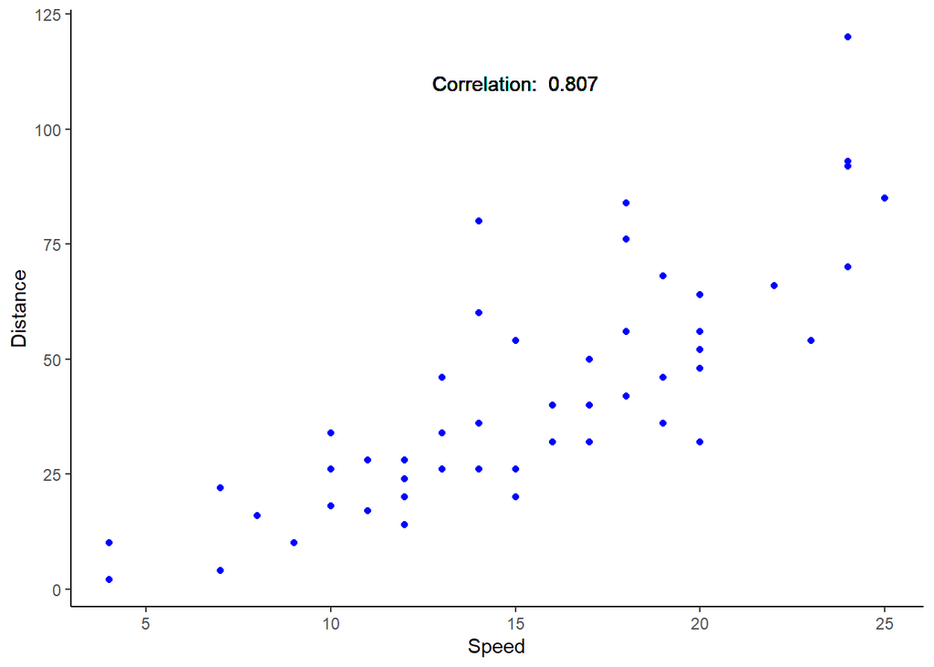

```r
cars_cor = paste('Correlation: ', round(cor(cars$speed, cars$dist), 3))
ggplot(data = cars, aes(x = speed, y = dist)) +
  geom_point(color = 'blue') +
  geom_text(x = 15, y = 110, label = cars_cor) +
  labs(x = 'Speed', y = 'Distance') +
  theme(panel.background = element_blank(),
        axis.line = element_line(color = 'black'))
```

### B.

Show a linear fit to the data on the plot.

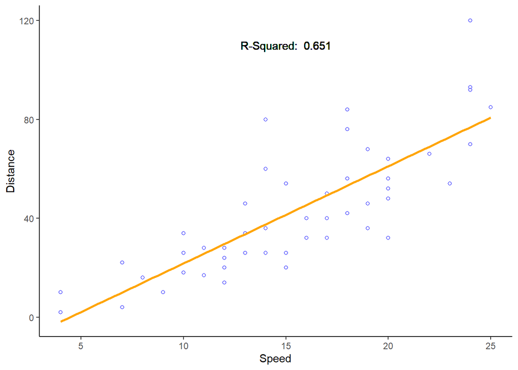

```r
cars_r2 = paste('R-Squared: ', round(summary(lin_cars)$r.sq, 3))
ggplot(data = cars, aes(x = speed, y = dist)) +
  geom_point(color = 'blue', pch = 1) +
  geom_smooth(method = 'lm', formula = y ~ x, se = FALSE, color = 'orange') +
  geom_text(x = 15, y = 110, label = cars_r2) +
  labs(x = 'Speed', y = 'Distance') +
  theme(panel.background = element_blank(),
        axis.line = element_line(color = 'black'))
```

### C.

Show a quadratic fit to the data on the plot.

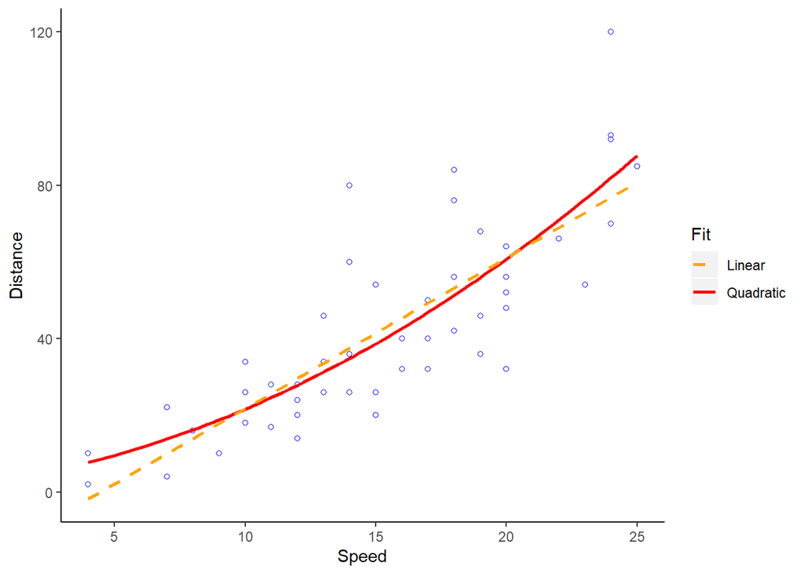

```r
ggplot(data = cars, aes(x = speed, y = dist)) +
  geom_point(color = 'blue', pch = 1) +
  geom_smooth(method = 'lm', formula = y ~ poly(x, 2, raw = TRUE),
              se = FALSE, aes(linetype = 'Quadratic', color = 'Quadratic')) +
  geom_smooth(method = 'lm', formula = y ~ x, se = FALSE,
              aes(linetype = 'Linear', color = 'Linear')) +
  labs(x = 'Speed', y = 'Distance', color = 'Fit', linetype = 'Fit') +
  theme(panel.background = element_blank(),
        axis.line = element_line(color = 'black')) +
  scale_linetype_manual(values = c('dashed', 'solid')) +
  scale_color_manual(values = c('orange', 'red'))
```

### D.

Now use sqrt(dist) as the response and fit a linear model. Show the fit on the same plot.

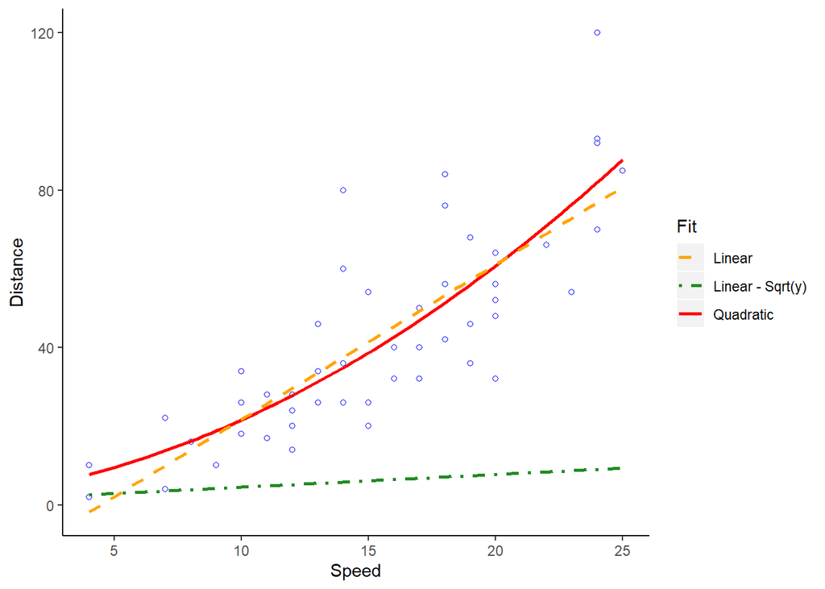

```r
ggplot(data = cars, aes(x = speed, y = dist)) +
  geom_point(color = 'blue', pch = 1) +
  geom_smooth(method = 'lm', formula = y ~ poly(x, 2, raw = TRUE),
              se = FALSE, aes(linetype = 'Quadratic', color = 'Quadratic')) +
  geom_smooth(method = 'lm', formula = y ~ x, se = FALSE,
              aes(linetype = 'Linear', color = 'Linear')) +
  geom_smooth(method = 'lm', formula = sqrt(y) ~ x, se = FALSE,
              aes(linetype = 'Linear - Sqrt(y)', color = 'Linear - Sqrt(y)')) +
  labs(x = 'Speed', y = 'Distance', color = 'Fit', linetype = 'Fit') +
  theme(panel.background = element_blank(),
        axis.line = element_line(color = 'black')) +
  scale_linetype_manual(values = c('dashed', 'dotdash', 'solid')) +
  scale_color_manual(values = c('orange', 'forestgreen', 'red'))
```

### E.

Compute the default smoothing spline fit to the plot and display on a fresh plot of the data. How does this compares with the previous fit?

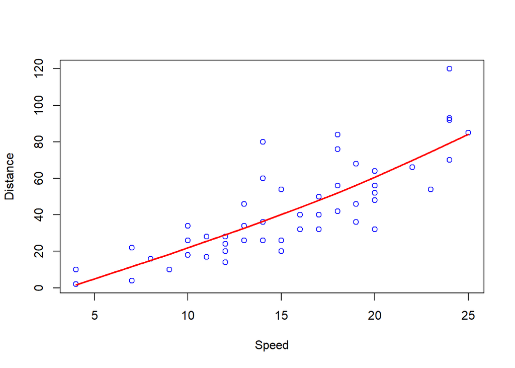

```r
plot(dist ~ speed, data = cars, pch = 1,
     xlab = 'Speed', ylab = 'Distance', col = 'blue')
lines(smooth.spline(cars$speed, cars$dist), lwd = 2, col = 'red')
```

Looking at the plot above, the default smoothing spline seems to fit the data quite well without any obvious overfitting.

Compared to the linear fit, the smoothing spline seems to go through the lower distance points which demonstrate an overall better fit.

Compared to the quadratic fit, the smoothing spline seems to fit the lower and mid speed points better. It also fits the high speed points as well as the quadratic.

Compared to the $\sqrt dist$ fit, the smoothing spline (as well as the other two fits) obviously fits much better. The square root model only passes through 1-2 data points, which is terrible.

Overall, the default smoothing spline seems to generate an overall better fit than previous models and should be considered for further testing of usefullness. It also indicates that our data may be of a non-parametric form.